# Dépenses publiques

# Introduction

Ce papier étudie les dépenses publiques d’éducation. Les sources sont trouvables sur le site de l’office fédéral de la statistique sous [la section Education et science](https://www.bfs.admin.ch/bfs/fr/home/statistiques/education-science.gnpdetail.2023-0303.html).

```r
library(readxl)
library(ggplot2)
library(dplyr)
library(tidyr)
library(stringr)
```

Nous commencerons par utiliser le fichier excel donné en premier, intitulé Dépenses publiques d’éducation depuis 1990: vue d’ensemble.xslx,

```r
raw_dataset <- read_xlsx("data/Dépenses publiques d'éducation depuis 1990 vue d'ensemble.xlsx", sheet = "je-15.06.01.03")
```

Ce papier n’a pas de but autre que de m’entraîner à jouer avec des données.

# Explorer le dataset

La première chose à faire face à un tableau est de l’explorer. Il est de bon temps de regarder les premières lignes et les dernières.

```r
head(raw_dataset,10)
```

| Dépenses publiques d'éducation depuis 1990: vue d'ensemble | ...2 | ...3 | ...4 | ...5 | ...6 | ...7 | T 15.06.01.03 |
| --- | --- | --- | --- | --- | --- | --- | --- |
| Valeurs nominales en millions de francs | NA | NA | NA | NA | NA | NA | NA |
| NA | Suisse | Confédération | Cantons | Communes | Dépenses publiques d'éducation en % du produit intérieur brut | Dépenses publiques d'éducation en % des dépenses publiques totales | NA |
| 1990 | 16609.723689999999 | 1556.271442 | 9780.7388759999994 | 5272.7133720000002 | 4.4988568855521098 | 15.7035602381209 | NA |
| 1991 | 18557.180809000001 | 1736.624636 | 10857.949354 | 5962.6068189999996 | 4.81248412078694 | 15.768474724583999 | NA |
| 1992 | 19978.441140999999 | 1872.446326 | 11635.085590000001 | 6470.9092250000003 | 5.0754945164904504 | 15.5525650397551 | NA |
| 1993 | 20506.014837999999 | 1978.39329 | 11930.230105000001 | 6597.3914430000004 | 5.0977248880933796 | 14.514037966575501 | NA |
| 1994 | 20768.548495999999 | 1995.290297 | 11991.429108 | 6781.8290909999996 | 5.0385781079537804 | 14.6072685775988 | NA |
| 1995 | 21053.069826999999 | 2022.4065680000001 | 12092.077789999999 | 6938.5854689999996 | 5.0459347484477703 | 14.8711406688194 | NA |
| 1996 | 21351.711669 | 2103.7782360000001 | 12284.666526999999 | 6963.2669059999998 | 5.0792844797322596 | 14.4496757804836 | NA |
| 1997 | 21380.133145 | 2020.4770060000001 | 12380.162705999999 | 6979.4934329999996 | 4.9973885369998197 | 14.081780281937601 | NA |

La fonction head() nous permet de voir qu’il y a un premier souci avec les noms de colonnes. En effet, le spreadsheet n’utilise pas la première ligne pour nommer les colonnes, mais la troisième. Nous devrons donc faire en sorte d’adapter le spreadsheet pour l’ordinateur tout en ne perdant pas les données écrites pour les utilisateurs humains.

```r
tail(raw_dataset,10)
```

| Dépenses publiques d'éducation depuis 1990: vue d'ensemble | ...2 | ...3 | ...4 | ...5 | ...6 | ...7 | T 15.06.01.03 |
| --- | --- | --- | --- | --- | --- | --- | --- |
| 2021 | 41335.001979000001 | 4141.7982769999999 | 25962.537323 | 11230.666379 | 5.5607858054144499 | 17.713188394097902 | NA |
| État: 11.12.2023 | NA | NA | NA | NA | NA | NA | NA |
| Les dépenses publiques consacrées à "Recherche fondamentale" et "R&D formation" sont incluses dans la statistique des dépenses publiques d'éducation. | NA | NA | NA | NA | NA | NA | NA |
| Les résultats sont consolidés, c’est-à-dire que les opérations entre différentes entités sont annulées lorsque les comptes de ces entités sont agrégés. Lorsque, par exemple, l'ensemble des cantons con… | NA | NA | NA | NA | NA | NA | NA |
| Les dépenses extraordinaires sont exclues. Les recettes de transfert provenant des autres unités des administrations publiques sont incluses (perspective des dépenses). | NA | NA | NA | NA | NA | NA | NA |
| NA | NA | NA | NA | NA | NA | NA | NA |
| Sources: OFS – Dépenses publiques d'éducation (ÖBA), Comptes nationaux (VGR); AFF – Statistique financière (SF) | NA | NA | NA | NA | NA | NA | NA |
| © OFS 2023 | NA | NA | NA | NA | NA | NA | NA |
| NA | NA | NA | NA | NA | NA | NA | NA |
| Renseignements: schulstat@bfs.admin.ch | NA | NA | NA | NA | NA | NA | NA |

La queue du dataset est également intéressante. On voit une ligne, celle de 2021, le reste est du texte pour le référencement.

```r
dataset_propre <- raw_dataset %>%
  filter(!row_number() %in% c(2)) %>%
  rename(
    "Année" = "Dépenses publiques d'éducation depuis 1990: vue d'ensemble",
    "Suisse" = "...2",
    "Confédération" = "...3",
    "Cantons" = "...4",
    "Communes" = "...5",
    "Dépenses publiques d'éducation en % du produit intérieur brut" = "...6",
    "Dépenses publiques d'éducation en % des dépenses publiques" = "...7") %>%
  filter(!row_number() %in% c(1,34,35,36,37,38,39,40,41,42)) %>%
  select(-"T 15.06.01.03") %>%
  mutate(across(
    c(
      Suisse,
      Confédération,
      Cantons,
      Communes,
      `Dépenses publiques d'éducation en % du produit intérieur brut`,
      `Dépenses publiques d'éducation en % des dépenses publiques`
      ), as.double)) %>%
  mutate(across(c(
    Suisse,
    Confédération,
    Cantons,
    Communes,
    `Dépenses publiques d'éducation en % du produit intérieur brut`,
    `Dépenses publiques d'éducation en % des dépenses publiques`
  ), round, 2))
```

Petite vérification du dataset.

```r
glimpse(dataset_propre)
```

```
## Rows: 32
## Columns: 7
## $ Année                                                           <chr> "1990"…
## $ Suisse                                                          <dbl> 16609.…
## $ Confédération                                                   <dbl> 1556.2…
## $ Cantons                                                         <dbl> 9780.7…
## $ Communes                                                        <dbl> 5272.7…
## $ `Dépenses publiques d'éducation en % du produit intérieur brut` <dbl> 4.50, …
## $ `Dépenses publiques d'éducation en % des dépenses publiques`    <dbl> 15.70,…
```

Maintenant que les données sont propres, nous pouvons commencer à comparer certaines valeurs.

La première comparaison que nous proposons est entre le total dépensé dans l’éducation, c’est-à-dire la colonne Suisse, avec les Dépenses publiques en pourcentage du produit intérieur brut.

On devrait s’attendre à une augmentation en diagonale, c’est-à-dire plus le pourcentage en PIB augmente, plus la somme totale de CHF investits dans l’éducation augmente.

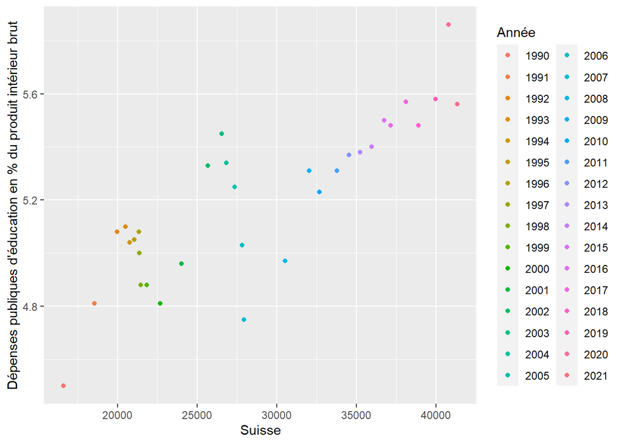

```r
ggplot(data=dataset_propre,
       mapping=aes(x=Suisse,
                   y=`Dépenses publiques d'éducation en % du produit intérieur brut`,
                   color = Année)) +
  geom_point()
```

Nous pouvons également comaprer les dépenses en Suisse avec le pourcentage des dépenses publiques.

Là, nous pouvons espérer deux scénarios, soit une constance dans le pourcentage des dépenses publiques, soit une hausse.

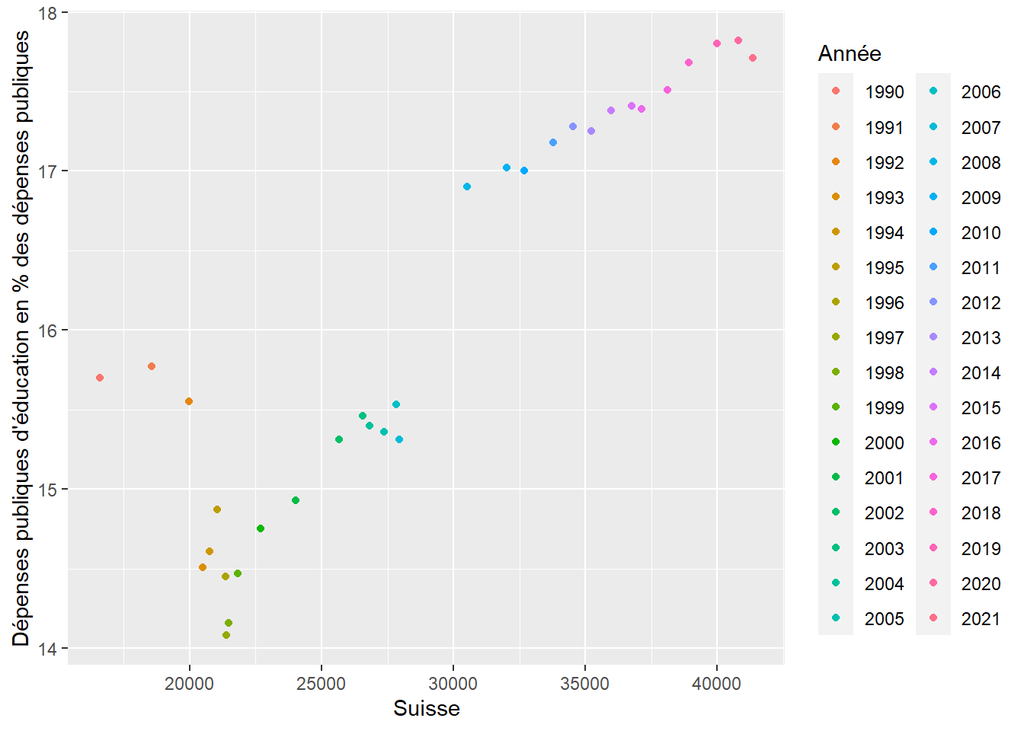

```r
ggplot(data=dataset_propre,
       mapping=aes(x=Suisse,
                   y=`Dépenses publiques d'éducation en % des dépenses publiques`,
                   color = Année)) +
  geom_point()
```

Les barrplots

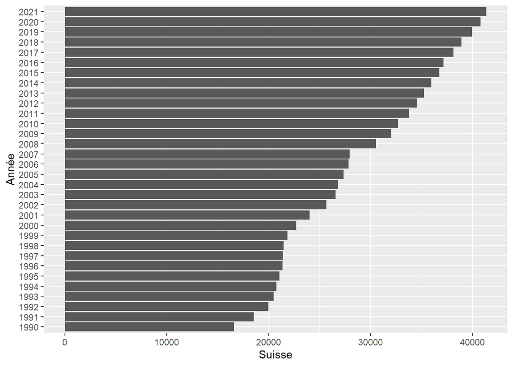

```r
ggplot(data = dataset_propre,
       mapping = aes(x = Année,
                     y = Suisse)) +
  geom_col() +
  coord_flip()
```